# RPR_Project_1

Mahdi Mirhosseini

11/2/2018

**A) Loading and preprocessing data / Pckgs**

```r
download.file("https://d396qusza40orc.cloudfront.net/repdata%2Fdata%2Factivity.zip", destfile = "activity.zip", mode="wb")
unzip("activity.zip")
Activity <- read.csv("activity.csv", header = TRUE)
library(knitr)
library(ggplot2)
head(Activity, 3)
```

```
##   steps       date interval
## 1    NA 2012-10-01        0
## 2    NA 2012-10-01        5
## 3    NA 2012-10-01       10
```

```r
str(Activity)
```

```
## 'data.frame':    17568 obs. of  3 variables:
##  $ steps   : int  NA NA NA NA NA NA NA NA NA NA ...
##  $ date    : Factor w/ 61 levels "2012-10-01","2012-10-02",..: 1 1 1 1 1 1 1 1 1 1 ...
##  $ interval: int  0 5 10 15 20 25 30 35 40 45 ...
```

```r
Activity$date <- as.Date(Activity$date)
summary(Activity)
```

```
##      steps             date               interval
##  Min.   :  0.00   Min.   :2012-10-01   Min.   :   0.0
##  1st Qu.:  0.00   1st Qu.:2012-10-16   1st Qu.: 588.8
##  Median :  0.00   Median :2012-10-31   Median :1177.5
##  Mean   : 37.38   Mean   :2012-10-31   Mean   :1177.5
##  3rd Qu.: 12.00   3rd Qu.:2012-11-15   3rd Qu.:1766.2
##  Max.   :806.00   Max.   :2012-11-30   Max.   :2355.0
##  NA's   :2304
```

```r
table(is.na(Activity$steps))
```

```
##
## FALSE  TRUE
## 15264  2304
```

**B) What is mean total number of steps taken per day?**

*1-a) Defining a new dataset to aggregate steps*

```r
ActByDay <- aggregate(Activity$steps, by=list(Activity$date), sum)
names(ActByDay) <- c("date", "SumSteps")
```

*1-b) Make a Histogram*

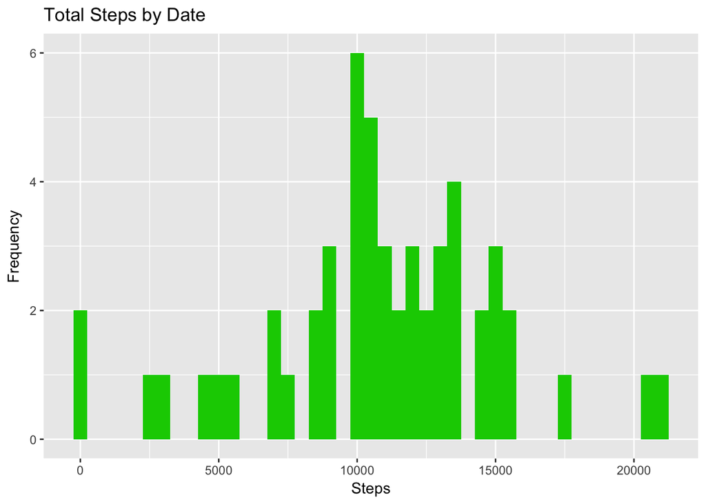

```r
ggplot(ActByDay, aes(x = SumSteps)) +
        geom_histogram(fill = "green3", binwidth=500) +
        labs(title = "Total Steps by Date", x = "Steps", y = "Frequency")
```

*2) Calculate and report the mean and median total number of steps taken per day*

```r
mean(ActByDay$SumSteps, na.rm = TRUE)
```

```
## [1] 10766.19
```

```r
median(ActByDay$SumSteps, na.rm = TRUE)
```

```
## [1] 10765
```

**C) What is the average daily activity pattern?**

*1) Make a time series plot of the 5-minute interval and the average steps*

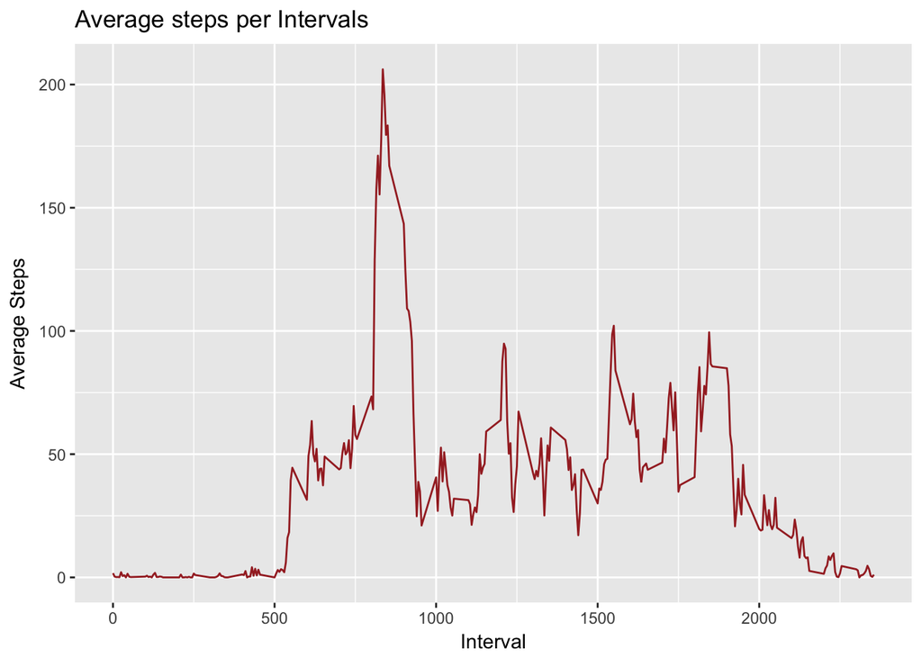

```r
Na_rm <- Activity[!is.na(Activity$steps),]
ActByIntrvl <- aggregate(Na_rm$steps, by=list(Na_rm$interval), mean)
names(ActByIntrvl) <- c("interval","mean_steps")
ggplot(ActByIntrvl, aes(x = interval, y = mean_steps)) +
        labs(title = "Average steps per Intervals",
             x = "Interval", y = "Average Steps") +
        geom_line(color="Brown")
```

*2) 5-minute interval with maximum number of steps?*

```r
ActByIntrvl[which(ActByIntrvl$mean_steps==max(ActByIntrvl$mean_steps)),]
```

```
##     interval mean_steps
## 104      835   206.1698
```

**D) Imputing missing values**

*1) Total number of missing values in the dataset*

```r
sum(is.na(Activity))
```

```
## [1] 2304
```

*2) Devise a strategy for filling in all of the missing values in the dataset*

```r
NA_Rplc <- replace(Activity$steps, is.na(Activity$steps),
                   round(mean(Activity$step, na.rm = TRUE),2))
Activity$steps <- NA_Rplc
```

*3) Create a new dataset; original DS with “missing data” filled in*

```r
New_Act <- Activity
```

*4-a) Make a histogram of the total number of steps taken each day*

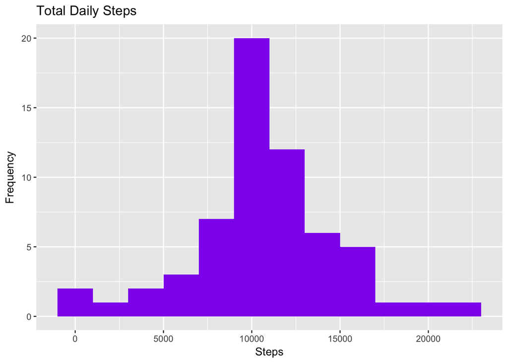

```r
SumActByDay <- aggregate(New_Act$steps, by=list(New_Act$date), sum)

names(SumActByDay) = c("Date", "Total_Steps")

ggplot(SumActByDay, aes(x = Total_Steps)) +
  geom_histogram(fill = "Purple2", binwidth=2000) +
  labs(title = "Total Daily Steps", x = "Steps", y = "Frequency")
```

*4-b) “mean” and “median” of daily number of steps and analysing the difference*

```r
OldMean <- mean(ActByDay$SumSteps, na.rm = TRUE)
paste("Mean of daily steps in Original dataset is   ", round(OldMean,2));
```

```
## [1] "Mean of daily steps in Original dataset is    10766.19"
```

```r
NewMean <- mean(SumActByDay$Total_Steps)
paste("Mean of daily steps in New dataset is        ", round(NewMean,2))
```

```
## [1] "Mean of daily steps in New dataset is         10766.09"
```

```r
OldMedian <- median(ActByDay$SumSteps, na.rm = TRUE)
paste("Median of daily steps in Original dataset is ", round(OldMedian,2))
```

```
## [1] "Median of daily steps in Original dataset is  10765"
```

```r
NewMedian <- median(SumActByDay$Total_Steps)
paste("Median of daily steps in New dataset is      ", round(NewMedian,2))
```

```
## [1] "Median of daily steps in New dataset is       10765.44"
```

```
## [1] "Explanation: As seen from above mentioned differences, using MEAN to replace the NAs, converged total number of steps toward its original mean. It makes more NORMALITY to the dataset by making Mean and Median more closer to each other."
```

**E) Are there differences in activity patterns between weekdays and weekends?**

*1) Create new FACTOR variable: “weekday” / “weekend” indicator of given day.*

```r
New_Act$date <- as.Date(New_Act$date)
New_Act$weekday <- weekdays(New_Act$date)
New_Act$DayType <- ifelse(New_Act$weekday=="Saturday"|New_Act$weekday=="Sunday",
                          "Weekend", "Weekday" )
New_Act$DayType <- as.factor(New_Act$DayType)
```

*2) Make a panel plot; time series of interval and steps’ average by DayType*

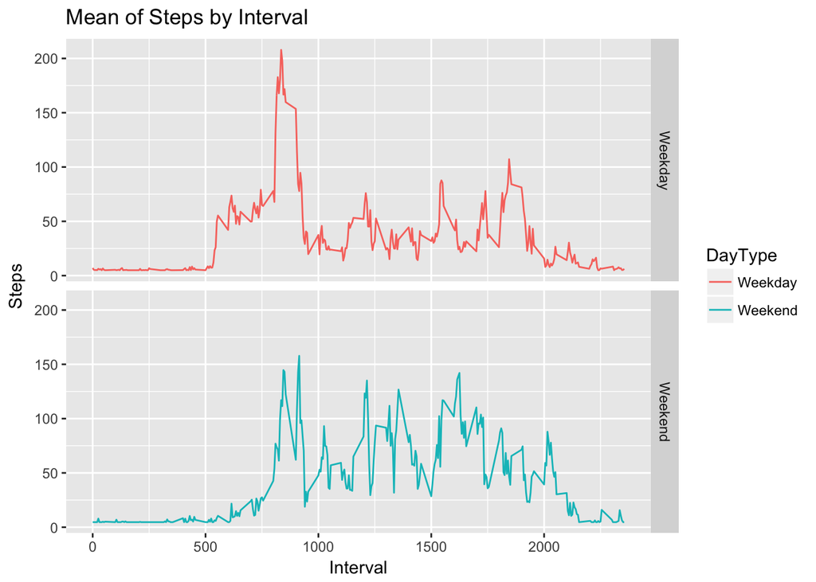

```r
MeanDayType <- aggregate(New_Act$steps,
                         by=list(New_Act$DayType, New_Act$interval), mean)

names(MeanDayType) =c("DayType", "Interval", "Steps")

ggplot(MeanDayType, aes(x = Interval, y=Steps, color=DayType)) +
        geom_line() +
        facet_grid(DayType ~ .) +
        labs(title = "Mean of Steps by Interval", x = "Interval", y = "Steps")
```